```python
# importing libiraries to be used
import pandas as pd
import numpy as np
import matplotlib.pyplot as plt
%matplotlib inline
import seaborn as sns
```

# Loading the data

loading the data to be cleaned and then analyzed

```python
#Loading data
df = pd.read_csv('data.csv')
df.head()
```

|  | Unnamed: 0 | ID | Name | Age | Photo | Nationality | Flag | Overall | Potential | Club | ... | Composure | Marking | StandingTackle | SlidingTackle | GKDiving | GKHandling | GKKicking | GKPositioning | GKReflexes | Release Clause |
| --- | --- | --- | --- | --- | --- | --- | --- | --- | --- | --- | --- | --- | --- | --- | --- | --- | --- | --- | --- | --- | --- |
| 0 | 0 | 158023 | L. Messi | 31 | https://cdn.sofifa.org/players/4/19/158023.png | Argentina | https://cdn.sofifa.org/flags/52.png | 94 | 94 | FC Barcelona | ... | 96.0 | 33.0 | 28.0 | 26.0 | 6.0 | 11.0 | 15.0 | 14.0 | 8.0 | €226.5M |
| 1 | 1 | 20801 | Cristiano Ronaldo | 33 | https://cdn.sofifa.org/players/4/19/20801.png | Portugal | https://cdn.sofifa.org/flags/38.png | 94 | 94 | Juventus | ... | 95.0 | 28.0 | 31.0 | 23.0 | 7.0 | 11.0 | 15.0 | 14.0 | 11.0 | €127.1M |
| 2 | 2 | 190871 | Neymar Jr | 26 | https://cdn.sofifa.org/players/4/19/190871.png | Brazil | https://cdn.sofifa.org/flags/54.png | 92 | 93 | Paris Saint-Germain | ... | 94.0 | 27.0 | 24.0 | 33.0 | 9.0 | 9.0 | 15.0 | 15.0 | 11.0 | €228.1M |
| 3 | 3 | 193080 | De Gea | 27 | https://cdn.sofifa.org/players/4/19/193080.png | Spain | https://cdn.sofifa.org/flags/45.png | 91 | 93 | Manchester United | ... | 68.0 | 15.0 | 21.0 | 13.0 | 90.0 | 85.0 | 87.0 | 88.0 | 94.0 | €138.6M |
| 4 | 4 | 192985 | K. De Bruyne | 27 | https://cdn.sofifa.org/players/4/19/192985.png | Belgium | https://cdn.sofifa.org/flags/7.png | 91 | 92 | Manchester City | ... | 88.0 | 68.0 | 58.0 | 51.0 | 15.0 | 13.0 | 5.0 | 10.0 | 13.0 | €196.4M |

5 rows × 89 columns

## There are 89 columns

Not all these columns will be used some of them are usless for the purpose of the analysis

```python
df.columns
```

```
Index(['Unnamed: 0', 'ID', 'Name', 'Age', 'Photo', 'Nationality', 'Flag',
       'Overall', 'Potential', 'Club', 'Club Logo', 'Value', 'Wage', 'Special',
       'Preferred Foot', 'International Reputation', 'Weak Foot',
       'Skill Moves', 'Work Rate', 'Body Type', 'Real Face', 'Position',
       'Jersey Number', 'Joined', 'Loaned From', 'Contract Valid Until',
       'Height', 'Weight', 'LS', 'ST', 'RS', 'LW', 'LF', 'CF', 'RF', 'RW',
       'LAM', 'CAM', 'RAM', 'LM', 'LCM', 'CM', 'RCM', 'RM', 'LWB', 'LDM',
       'CDM', 'RDM', 'RWB', 'LB', 'LCB', 'CB', 'RCB', 'RB', 'Crossing',
       'Finishing', 'HeadingAccuracy', 'ShortPassing', 'Volleys', 'Dribbling',
       'Curve', 'FKAccuracy', 'LongPassing', 'BallControl', 'Acceleration',
       'SprintSpeed', 'Agility', 'Reactions', 'Balance', 'ShotPower',
       'Jumping', 'Stamina', 'Strength', 'LongShots', 'Aggression',
       'Interceptions', 'Positioning', 'Vision', 'Penalties', 'Composure',
       'Marking', 'StandingTackle', 'SlidingTackle', 'GKDiving', 'GKHandling',
       'GKKicking', 'GKPositioning', 'GKReflexes', 'Release Clause'],
      dtype='object')
```

## Usless columns

ID

Photo

Flag

Club Logo

Special

Jersey Number

Loaned From

Contract Valid Until

Release Clause

GKDiving

GKHandling

GKKicking

GKPositioning

GKReflexes

Reactions

Balance

(All position cols)

```python
# Checking for duplicated rows and
df.duplicated().sum()
```

```
0
```

## Assessing data to get more info about it

```python
df.describe()
```

|  | Unnamed: 0 | ID | Age | Overall | Potential | Special | International Reputation | Weak Foot | Skill Moves | Jersey Number | ... | Penalties | Composure | Marking | StandingTackle | SlidingTackle | GKDiving | GKHandling | GKKicking | GKPositioning | GKReflexes |
| --- | --- | --- | --- | --- | --- | --- | --- | --- | --- | --- | --- | --- | --- | --- | --- | --- | --- | --- | --- | --- | --- |
| count | 18207.000000 | 18207.000000 | 18207.000000 | 18207.000000 | 18207.000000 | 18207.000000 | 18159.000000 | 18159.000000 | 18159.000000 | 18147.000000 | ... | 18159.000000 | 18159.000000 | 18159.000000 | 18159.000000 | 18159.000000 | 18159.000000 | 18159.000000 | 18159.000000 | 18159.000000 | 18159.000000 |
| mean | 9103.000000 | 214298.338606 | 25.122206 | 66.238699 | 71.307299 | 1597.809908 | 1.113222 | 2.947299 | 2.361308 | 19.546096 | ... | 48.548598 | 58.648274 | 47.281623 | 47.697836 | 45.661435 | 16.616223 | 16.391596 | 16.232061 | 16.388898 | 16.710887 |
| std | 5256.052511 | 29965.244204 | 4.669943 | 6.908930 | 6.136496 | 272.586016 | 0.394031 | 0.660456 | 0.756164 | 15.947765 | ... | 15.704053 | 11.436133 | 19.904397 | 21.664004 | 21.289135 | 17.695349 | 16.906900 | 16.502864 | 17.034669 | 17.955119 |
| min | 0.000000 | 16.000000 | 16.000000 | 46.000000 | 48.000000 | 731.000000 | 1.000000 | 1.000000 | 1.000000 | 1.000000 | ... | 5.000000 | 3.000000 | 3.000000 | 2.000000 | 3.000000 | 1.000000 | 1.000000 | 1.000000 | 1.000000 | 1.000000 |
| 25% | 4551.500000 | 200315.500000 | 21.000000 | 62.000000 | 67.000000 | 1457.000000 | 1.000000 | 3.000000 | 2.000000 | 8.000000 | ... | 39.000000 | 51.000000 | 30.000000 | 27.000000 | 24.000000 | 8.000000 | 8.000000 | 8.000000 | 8.000000 | 8.000000 |
| 50% | 9103.000000 | 221759.000000 | 25.000000 | 66.000000 | 71.000000 | 1635.000000 | 1.000000 | 3.000000 | 2.000000 | 17.000000 | ... | 49.000000 | 60.000000 | 53.000000 | 55.000000 | 52.000000 | 11.000000 | 11.000000 | 11.000000 | 11.000000 | 11.000000 |
| 75% | 13654.500000 | 236529.500000 | 28.000000 | 71.000000 | 75.000000 | 1787.000000 | 1.000000 | 3.000000 | 3.000000 | 26.000000 | ... | 60.000000 | 67.000000 | 64.000000 | 66.000000 | 64.000000 | 14.000000 | 14.000000 | 14.000000 | 14.000000 | 14.000000 |
| max | 18206.000000 | 246620.000000 | 45.000000 | 94.000000 | 95.000000 | 2346.000000 | 5.000000 | 5.000000 | 5.000000 | 99.000000 | ... | 92.000000 | 96.000000 | 94.000000 | 93.000000 | 91.000000 | 90.000000 | 92.000000 | 91.000000 | 90.000000 | 94.000000 |

8 rows × 44 columns

```python
df.info()
```

```
<class 'pandas.core.frame.DataFrame'>
RangeIndex: 18207 entries, 0 to 18206
Data columns (total 89 columns):
 #   Column                    Non-Null Count  Dtype
---  ------                    --------------  -----
 0   Unnamed: 0                18207 non-null  int64
 1   ID                        18207 non-null  int64
 2   Name                      18207 non-null  object
 3   Age                       18207 non-null  int64
 4   Photo                     18207 non-null  object
 5   Nationality               18207 non-null  object
 6   Flag                      18207 non-null  object
 7   Overall                   18207 non-null  int64
 8   Potential                 18207 non-null  int64
 9   Club                      17966 non-null  object
```

[output cut: 81 more lines]

## Cleaning the data and adjusting data types

```python
# making a copy of the original df to clean it
df_clean = df.copy()
```

```python
#useless columns to be removed
cols = ['ID','Photo', 'Flag','Club Logo','Special','Jersey Number','Loaned From','Contract Valid Until',
        'Release Clause','GKDiving', 'GKHandling','GKKicking', 'GKPositioning', 'GKReflexes','Reactions',
        'Balance', 'LS', 'ST', 'RS', 'LW', 'LF','CF', 'RF', 'RW', 'LAM', 'CAM', 'RAM', 'LM', 'LCM', 'CM',
        'RCM', 'RM', 'LWB', 'LDM','CDM', 'RDM', 'RWB', 'LB', 'LCB', 'CB', 'RCB', 'RB', 'Unnamed: 0']
```

```python
#drop the useless columns it's better to make a list of the columns and then drop them
df_clean.drop(columns=cols,inplace=True)
```

```python
df_clean.info()
```

```
<class 'pandas.core.frame.DataFrame'>
RangeIndex: 18207 entries, 0 to 18206
Data columns (total 46 columns):
 #   Column                    Non-Null Count  Dtype
---  ------                    --------------  -----
 0   Name                      18207 non-null  object
 1   Age                       18207 non-null  int64
 2   Nationality               18207 non-null  object
 3   Overall                   18207 non-null  int64
 4   Potential                 18207 non-null  int64
 5   Club                      17966 non-null  object
 6   Value                     18207 non-null  object
 7   Wage                      18207 non-null  object
 8   Preferred Foot            18159 non-null  object
 9   International Reputation  18159 non-null  float64
```

[output cut: 38 more lines]

```python
#the unit of Wage column is in thousand
#in this cell i'm cleaning the Wage cool from the signs that indicate currencey and amount
df_clean.Wage = df_clean.Wage.apply(lambda x: str(x).replace('€',''))
df_clean.Wage = df_clean.Wage.apply(lambda x: str(x).replace('K',''))
df_clean.Wage = df_clean.Wage.astype(float)
```

```python
#the unit of Value column is in million
#in this cell i'm cleaning the Wage cool from the signs that indicate currencey and amount
df_clean.Value = df_clean.Value.apply(lambda x: str(x).replace('€',''))
df_clean.Value = df_clean.Value.apply(lambda x: str(x).replace('K','000'))
df_clean.Value = df_clean.Value.apply(lambda x: str(x).replace('M','00000') \
                                      if '.' in str(x) else str(x).replace('M','000000') )
df_clean.Value = df_clean.Value.apply(lambda x: str(x).replace('.',''))
df_clean.Value = df_clean.Value.astype(float)
df_clean.Value = df_clean.Value / 10**6
```

```python
#Saving the clean df into csv to use it in the slide deck file to not clean it again there
df_clean.to_csv('clean_df.csv',index = False)
```

```python
#taking the most important columns to work with them instead of taking 40+ cols and not use them all
df_sal = df_clean[['Name', 'Age', 'Overall', 'Potential','Club', 'Value', 'Wage',
                   'Preferred Foot', 'Position','Stamina','ShotPower','International Reputation']].copy()
df_sal.head()
```

|  | Name | Age | Overall | Potential | Club | Value | Wage | Preferred Foot | Position | Stamina | ShotPower | International Reputation |
| --- | --- | --- | --- | --- | --- | --- | --- | --- | --- | --- | --- | --- |
| 0 | L. Messi | 31 | 94 | 94 | FC Barcelona | 110.5 | 565.0 | Left | RF | 72.0 | 85.0 | 5.0 |
| 1 | Cristiano Ronaldo | 33 | 94 | 94 | Juventus | 77.0 | 405.0 | Right | ST | 88.0 | 95.0 | 5.0 |
| 2 | Neymar Jr | 26 | 92 | 93 | Paris Saint-Germain | 118.5 | 290.0 | Right | LW | 81.0 | 80.0 | 5.0 |
| 3 | De Gea | 27 | 91 | 93 | Manchester United | 72.0 | 260.0 | Right | GK | 43.0 | 31.0 | 4.0 |
| 4 | K. De Bruyne | 27 | 91 | 92 | Manchester City | 102.0 | 355.0 | Right | RCM | 90.0 | 91.0 | 4.0 |

```python
#dropping na values and checking if there is any left
df_sal.dropna(inplace=True)
df_sal.isnull().sum()
```

```
Name                        0
Age                         0
Overall                     0
Potential                   0
Club                        0
Value                       0
Wage                        0
Preferred Foot              0
Position                    0
Stamina                     0
ShotPower                   0
International Reputation    0
dtype: int64
```

# Univariate exploration

## Which Club is willing to pay above average Wage

**why i specifically wanted to know the top clubs in paying wage?**

to see if paying more is winning more and it really looks like that having better players that ask for more money results in winning more

```python
#in this cell i grouped the the data by Clubs and arranged them by total wage paied to get a top 10 list
#top clubs that pay wage
wage = df_sal.groupby(['Club'],as_index=False)['Wage'].sum()
top10_w = wage.sort_values(ascending = False,by='Wage')[:10]
top10_w['Wage'] = top10_w['Wage']/10**3
top10_w
```

|  | Club | Wage |
| --- | --- | --- |
| 470 | Real Madrid | 5.017 |
| 212 | FC Barcelona | 4.837 |
| 374 | Manchester City | 3.741 |
| 375 | Manchester United | 3.391 |
| 326 | Juventus | 3.292 |
| 134 | Chelsea | 3.249 |
| 363 | Liverpool | 2.902 |
| 583 | Tottenham Hotspur | 2.623 |
| 52 | Arsenal | 2.588 |
| 214 | FC Bayern München | 2.286 |

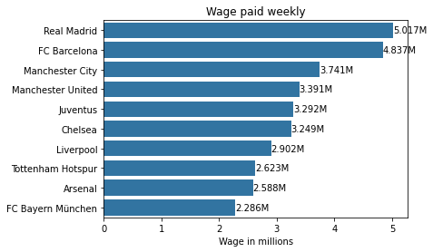

```python
#visualizing the outcome
clubs = list(top10_w.Club)
base_color = sns.color_palette()[0]
plt.title('Wage paid weekly')
sns.barplot(x=top10_w['Wage'],y= clubs,data = top10_w,color = base_color)
plt.xlabel('Wage in millions');
for i in range(10):
    weekly_wage = list(top10_w[top10_w.Club.str.startswith(clubs[i])]['Wage'])[0]
    pct_string = f'{str(weekly_wage)}M'
    plt.text(weekly_wage, i, pct_string, va='center')
```

## Clubs that have the most valuable players

**What this plot proves?**

this plot proves that paying more is winning more most of the last top 10 list is here in this plot and there is something in common in between all these clubs that they all are popualr and have a decent chang in winnig big titles

```python
#total value of players in clubs
value = df_sal.groupby(['Club'],as_index=False)['Value'].sum()
top10_v = value.sort_values(ascending = False,by='Value')[:10]
top10_v['Value'] = top10_v['Value'].round(3)
top10_v
```

|  | Club | Value |
| --- | --- | --- |
| 470 | Real Madrid | 874.425 |
| 212 | FC Barcelona | 852.600 |
| 374 | Manchester City | 786.555 |
| 326 | Juventus | 704.475 |
| 214 | FC Bayern München | 679.025 |
| 61 | Atlético Madrid | 644.525 |
| 435 | Paris Saint-Germain | 625.325 |
| 583 | Tottenham Hotspur | 618.450 |
| 134 | Chelsea | 606.815 |
| 375 | Manchester United | 588.850 |

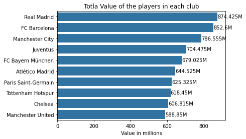

```python
#visualizing the outcome
clubs_v = list(top10_v.Club)
base_color = sns.color_palette()[0]
plt.title('Totla Value of the players in each club')
sns.barplot(x=top10_v.Value, y=clubs_v, data=top10_v, color=base_color)
plt.xlabel('Value in millions');
for i in range(10):
    total_value = list(top10_v[top10_v.Club.str.startswith(clubs_v[i])]['Value'])[0]
    pct_string = f'{str(total_value)}M'
    plt.text(total_value, i, pct_string, va='center')
```

## Top 10 paid players

**who are the top paid players and why are they top paid?**

```python
player = df_sal.groupby(['Name'],as_index=False)['Wage'].sum()
top10_p = player.sort_values(ascending = False,by='Wage')[:10]
top10_p['Wage'] = top10_p['Wage'].round(3)
top10_p
```

|  | Name | Wage |
| --- | --- | --- |
| 9466 | L. Messi | 565.0 |
| 9671 | L. Suárez | 481.0 |
| 9474 | L. Modrić | 420.0 |
| 3090 | Cristiano Ronaldo | 405.0 |
| 7776 | J. Rodríguez | 380.0 |
| 15169 | Sergio Ramos | 380.0 |
| 11667 | Marcelo | 362.0 |
| 8472 | K. De Bruyne | 355.0 |
| 15542 | T. Kroos | 355.0 |
| 5418 | G. Bale | 355.0 |

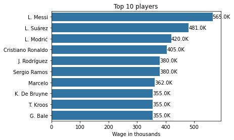

```python
players = list(top10_p.Name)
plt.title('Top 10 players')
sns.barplot(x=top10_p.Wage, y=players, data=top10_p, color=base_color)
plt.xlabel('Wage in thousands');
for i in range(10):
    total_value = list(top10_p[top10_p.Name.str.startswith(players[i])]['Wage'])[0]
    pct_string = f'{str(total_value)}K'
    plt.text(total_value, i, pct_string, va='center')
```

## Players positions

the purpose of this plot is to see what are the most wanted positions in soccer and looks like they are ST and GK

```python
df_sal.Position.value_counts()
```

```
ST     2130
GK     1992
CB     1754
CM     1377
LB     1305
RB     1268
RM     1114
LM     1086
CAM     948
CDM     936
RCB     652
LCB     637
LCM     389
RCM     387
LW      374
RW      365
RDM     246
LDM     239
LS      206
RS      201
RWB      87
LWB      78
CF       74
LAM      21
RAM      21
RF       16
LF       15
Name: Position, dtype: int64
```

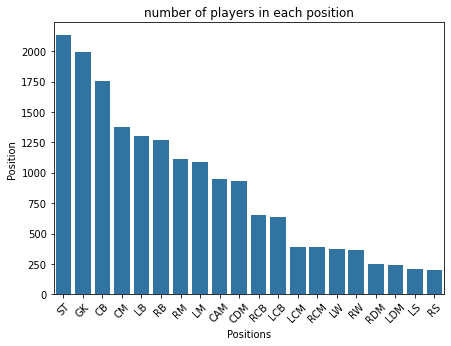

```python
#positions arranged according to how many players are in that position
p = df_sal.Position.value_counts()[:20]
plt.figure(figsize=[7,5])
sns.barplot(x=p.keys(),y=p,color=base_color)
plt.xlabel('Positions')
plt.title('number of players in each position')
plt.xticks(rotation=45);
```

# Bivariate exploration

## Relation between age and International Reputation

**The reason i made this plot is:**

to see the relation between international reputation of the player and there age and it proves my theory about the age sweet spot the players with high Rep are in their 30's

```python
df_clean['International Reputation'].value_counts()
```

```
1.0    16532
2.0     1261
3.0      309
4.0       51
5.0        6
Name: International Reputation, dtype: int64
```

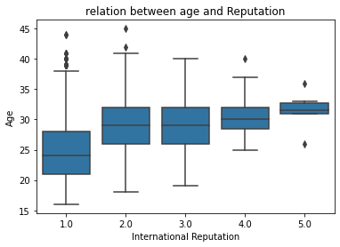

```python
#box plot to show th relation between age and rep
sns.boxplot(data=df_sal,y='Age',x='International Reputation',color=base_color)
plt.ylabel('Age')
plt.xlabel('International Reputation')
plt.title('relation between age and Reputation');
```

**As we see in the previous visualization that compares age and reputation of the players and reputation is from 1 to 5 and 5 is the highest majorty of players as we see have one and only few got 5, I also noticed that as the reputation score increses the box plot is not as spread which and it shrinks on both sides wich means that players need to be not only have crazy status but also have experience and looks like ages between 25 to 35 is where players have 4 and 5 rep points because usally this is the prime years of a player**

## Relation between Overall and Wage

**Why i made this plot?**

to see if the there is a +ve linear relation between wage and overall it's +ve but it's not linear

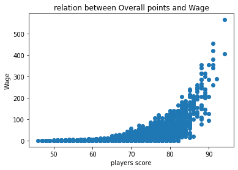

```python
#scatter plot shows the relation between overall and wage
plt.scatter(data=df_sal,x='Overall',y='Wage')
plt.xlabel('players score')
plt.ylabel('Wage')
plt.title('relation between Overall points and Wage');
```

## Relation between Potential and Rep

**Why i made this plot?**

i chose violin plot for this to show the distribution of data and see the relation between potential and reputation

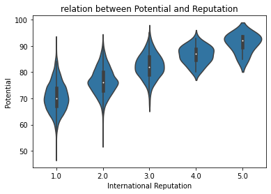

```python
#violin plot shows the relation between rep and potential of a player
sns.violinplot(data=df_sal,y='Potential',x='International Reputation',color=base_color)
plt.ylabel('Potential')
plt.xlabel('International Reputation')
plt.title('relation between Potential and Reputation');
```

**In the last visualization we see that as the potential of players increase rep shrinks high rep like 4 and 5 is only for palyers in range 80's to 90's and there are not outliers but in the ranks 1 and 2 there is ton of outliers from that visual it seems that rep depends on many things potential is one of them but it's not a main reason because there is a lot of rank 2 players in the range of rank 4 and 5**

# multivariate exploration

## Relation between Overall, Wage and International Reputation

**why i made this plot?**

to check if all players with high rep get paied well and if they have high overall points and they all have high overall but there are 2 players who are underpaid or maybe it's just noise in the data

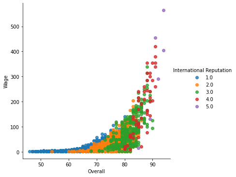

```python
#scatter plot between overall and wage with rep as a hue
sns.lmplot(x='Overall',y='Wage', hue='International Reputation',
           data=df_sal.loc[df_sal['Preferred Foot'].isin(['Left', 'Right'])],
           fit_reg=False);
```

```python
#correlation between('ShotPower', 'Jumping', 'Stamina', 'Strength')
df_clean[['ShotPower', 'Jumping', 'Stamina', 'Strength']].corr()
```

|  | ShotPower | Jumping | Stamina | Strength |
| --- | --- | --- | --- | --- |
| ShotPower | 1.000000 | 0.185823 | 0.616385 | 0.169515 |
| Jumping | 0.185823 | 1.000000 | 0.345968 | 0.284021 |
| Stamina | 0.616385 | 0.345968 | 1.000000 | 0.262694 |
| Strength | 0.169515 | 0.284021 | 0.262694 | 1.000000 |

## The next plot is a heat map that shows the relation between some variabels

**the purpose of this heat map is:**

to discover relations between some variabelsand as it shows value, potential, overall and wage have a +ve relation with reputation

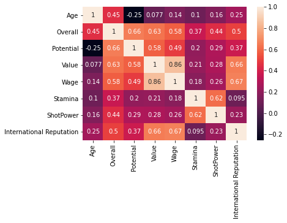

```python
#heatmap shows the relation between (age,overall,potential,value,wage,stamina,shotpower,international reputation)
sns.heatmap(df_sal.corr(), annot=True);
```